# sc_mixology dataset quality control using DropletQC

Author

Valerio Reffo

Published

June 6, 2028

```r
library(DropletQC)
library(purrr)
library(ggplot2)
library(patchwork)
library(dplyr)
library(scuttle)
library(scran)
library(scater)
library(anndataR)
library(SingleCellExperiment)
```

## Data Loading and Nuclear Fraction Calculation

```r
# Load the main mixology SCE object
sc_mix <- readRDS("/projects/shared/intronic_bam/datasets/sc_mixology/sc_mix.RDS")
sc_mix
```

[output not shown]

Let’s read the anndata with the embeddings matrix

```r
# Path automatically adapted for sc_mixology
mix_ann <- read_h5ad("/projects/shared/intronic_bam/datasets/anndata/mix_scGPT_embeddings.h5ad")
mix_ann
```

Add it into the reducedDim slot of the sce

```r
scgpt_matrix <- as.matrix(mix_ann$obsm['X_scGPT']$X_scGPT)
scgpt_matrix_aligned <- scgpt_matrix[colnames(sc_mix), ]
reducedDim(sc_mix, "scGPT") <- scgpt_matrix_aligned
```

### Exonic Fraction Processing and Metric Annotation

We inspect the global exonic mapping proportions and compute the true total sequenced reads per cell to accurately derive the nuclear fraction metric.

```r
# Inspect baseline exonic metrics
hist(prop.table(sc_mix$mapped_to_exon))
summary(sc_mix$mapped_to_exon)
head(colData(sc_mix))

# Calculate the total raw sequenced reads for each individual cell
total_sequenced_reads <- colData(sc_mix)$unaligned +
  colData(sc_mix)$aligned_unmapped +
  colData(sc_mix)$mapped_to_exon +
  colData(sc_mix)$mapped_to_intron +
  colData(sc_mix)$ambiguous_mapping +
  colData(sc_mix)$mapped_to_MT +
  colData(sc_mix)$mapped_to_ERCC

# Calculate the precise nuclear fraction and store it in colData
colData(sc_mix)$nuclear_fraction <- (colData(sc_mix)$mapped_to_intron / total_sequenced_reads)
```

[output not shown]

## Exploratory Analysis

We visualize the distribution of our newly calculated nuclear fraction across the distinct cell lines and explore its scaling relationship with total UMI counts.

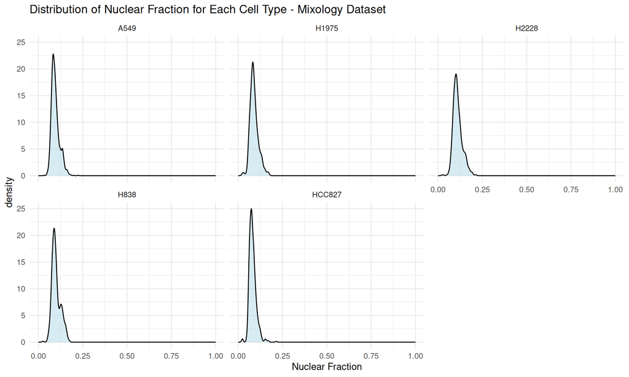

```r
# Nuclear fraction distribution profile faceted by cell line
p <- ggplot(as.data.frame(colData(sc_mix)), aes(x = nuclear_fraction))

p + geom_density(fill = "lightblue", alpha = 0.5) +
  facet_wrap(~cell_line) +
  theme_minimal() +
  labs(title = "Distribution of Nuclear Fraction for Each Cell Type - Mixology Dataset",
       x = "Nuclear Fraction") +
  xlim(c(0, 1))
```

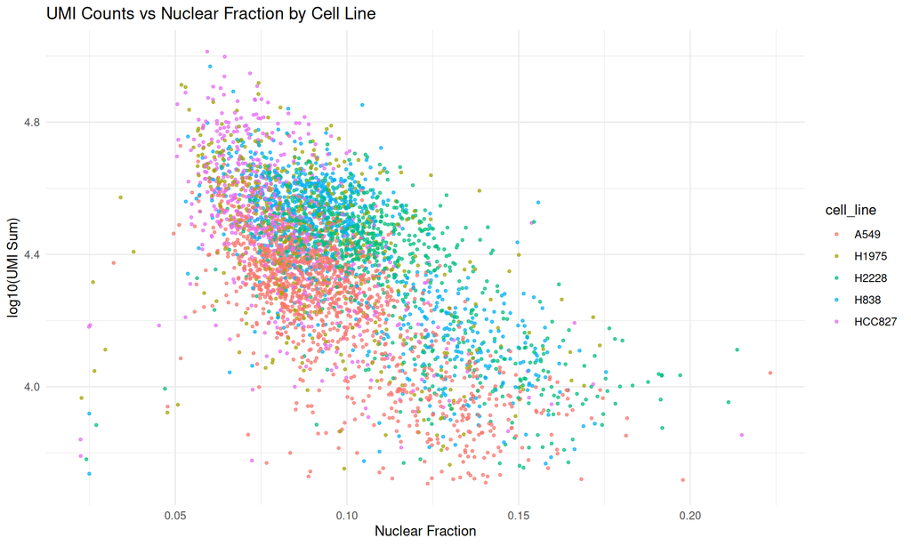

```r
# UMI counts vs Nuclear Fraction distribution profile
p + aes(y = log10(sum), colour = cell_line) +
  geom_point(alpha = 0.7, size = 0.8) +
  theme_minimal() +
  labs(title = "UMI Counts vs Nuclear Fraction by Cell Line",
       x = "Nuclear Fraction",
       y = "log10(UMI Sum)")
```

## Normalization and Dimensionality Reduction

We perform log-transformation normalization on the raw counts, model features to extract the Top 10% Highly Variable Genes (HVGs), and generate low-dimensional embeddings.

```r
sc_mix <- logNormCounts(sc_mix)
dec <- modelGeneVar(sc_mix)
hvgs <- getTopHVGs(dec, prop = 0.1)

sc_mix <- runPCA(sc_mix, subset_row = hvgs, ncomponents = 50)
sc_mix <- runUMAP(sc_mix, dimred = "PCA")
sc_mix
```

Let’s calculate the UMAP on the embeddings too

```r
sc_mix <- runUMAP(sc_mix, dimred = "scGPT", name = "UMAP_embed")
```

### Visualizing Embeddings (PCA vs UMAP)

We display the low-dimensional projection spaces side-by-side, assessing separation performance across cell lines and variations driven by the nuclear fraction values.

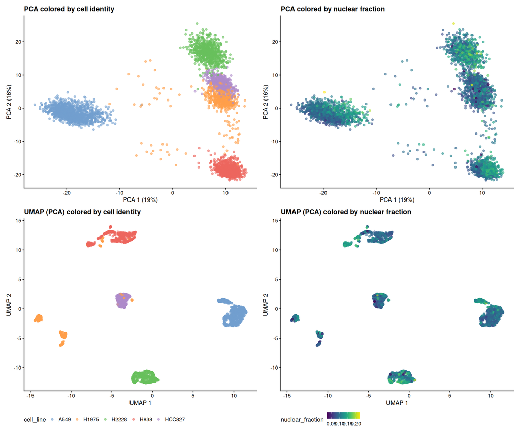

```r
# Cell identity
umapp <- plotUMAP(sc_mix, colour_by = "cell_line", dimred = "UMAP") +
  theme(legend.position = "bottom") +
  labs(title = "UMAP (PCA) colored by cell identity")
pcap  <- plotPCA(sc_mix, colour_by = "cell_line") +
  theme(legend.position = "none") +
  labs(title = "PCA colored by cell identity")

# Nuclear Fraction
umapb <- plotUMAP(sc_mix, colour_by = "nuclear_fraction", dimred = "UMAP") +
  theme(legend.position = "bottom") +
  labs(title = "UMAP (PCA) colored by nuclear fraction")
pcab  <- plotPCA(sc_mix, colour_by = "nuclear_fraction") +
  theme(legend.position = "none") +
  labs(title = "PCA colored by nuclear fraction")

# Umap embeddings
umapes <- plotUMAP(sc_mix, colour_by = "cell_line", dimred = "UMAP_embed") +
  theme(legend.position = "bottom") +
  labs(title = "UMAP (Embeddings) colored by cell identity")
umape <- plotUMAP(sc_mix, colour_by = "nuclear_fraction", dimred = "UMAP_embed") +
  theme(legend.position = "bottom") +
  labs(title = "UMAP (Embeddings) colored by nuclear fraction")

# Composite multi-panel layout
(pcap | pcab) / (umapp | umapb)
```

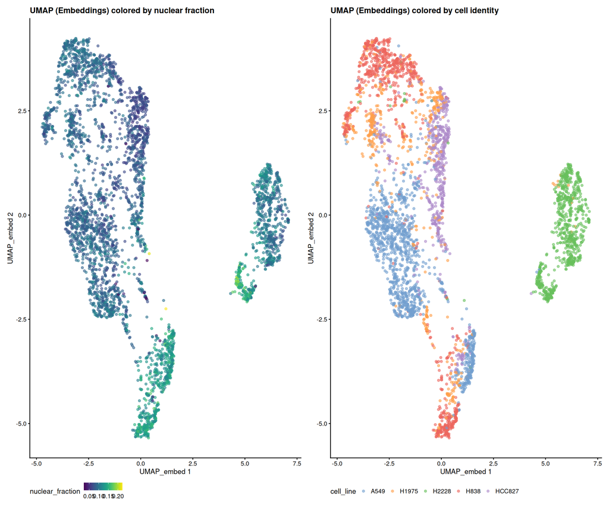

```r
(umape | umapes)
```

## Focus on MALAT1 and Nuclear Fraction Relationship

We evaluate the behavior of the nuclear-retained long non-coding RNA **MALAT1** to biologically validate our nuclear fraction metric.

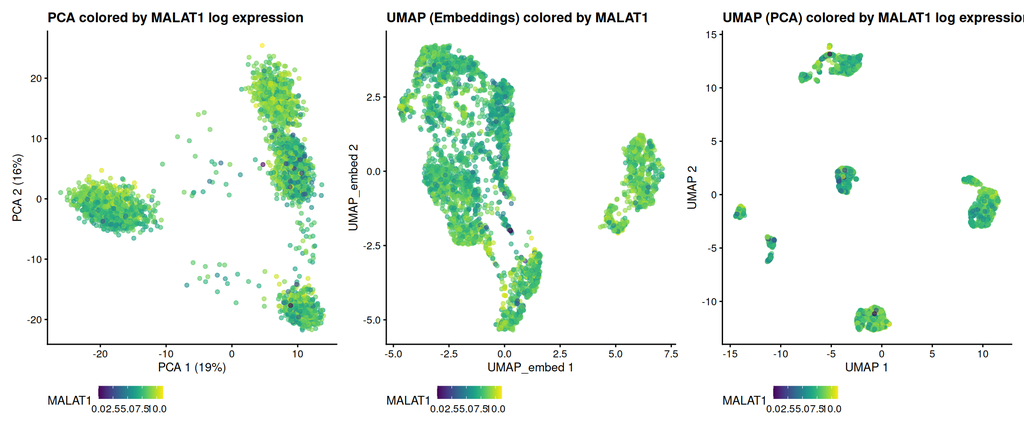

```r
umapm <- plotUMAP(sc_mix, colour_by = "MALAT1") + theme(legend.position = "bottom") +
  labs(title = "UMAP (PCA) colored by MALAT1 log expression")
pcam  <- plotPCA(sc_mix, colour_by = "MALAT1") + theme(legend.position = "bottom") +
  labs(title = "PCA colored by MALAT1 log expression")
umapem <- plotUMAP(sc_mix, colour_by = "MALAT1", dimred = "UMAP_embed") + theme(legend.position = "bottom") +
  labs(title = "UMAP (Embeddings) colored by MALAT1")

# Direct comparison in reduced dimensions
pcam | umapem | umapm
```

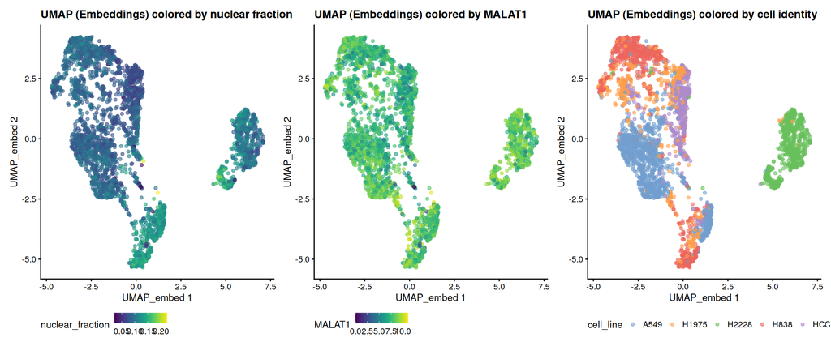

```r
umape | umapem | umapes
```

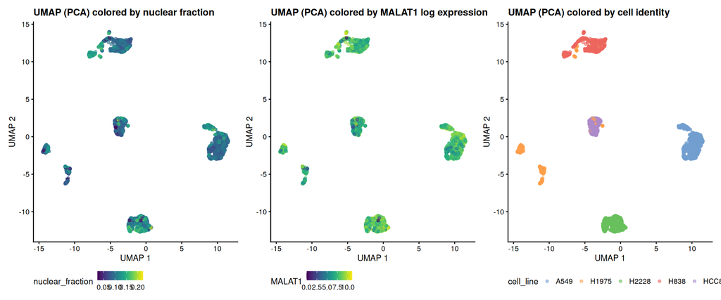

```r
umapb | umapm | umapp
```

### MALAT1 vs Nuclear Fraction Scatter Plot Faceted by Cell Line

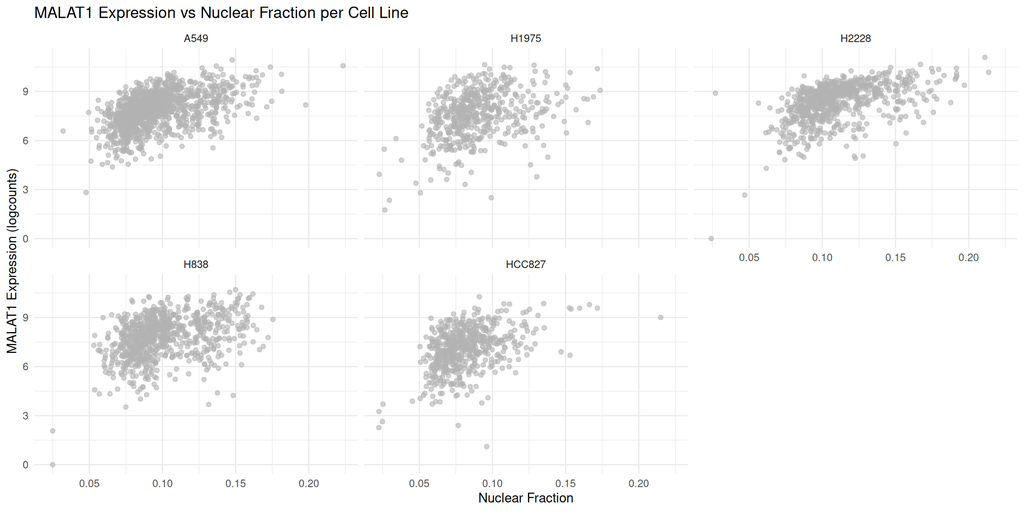

```r
plotExpression(sc_mix,
               features = "MALAT1",
               x = "nuclear_fraction",
               other_fields = "cell_line",
               exprs_values = "logcounts") +
  facet_wrap(~cell_line) +
  aes(color = cell_line) +
  theme_minimal() +
  labs(title = "MALAT1 Expression vs Nuclear Fraction per Cell Line",
       x = "Nuclear Fraction",
       y = "MALAT1 Expression (logcounts)")
```

## Detecting Empty Droplets and Damaged Cells with `DropletQC`

We compile the nuclear fraction values and total UMI counts into a structural dataframe, filter out empty observations, and compute the cell status profiles.

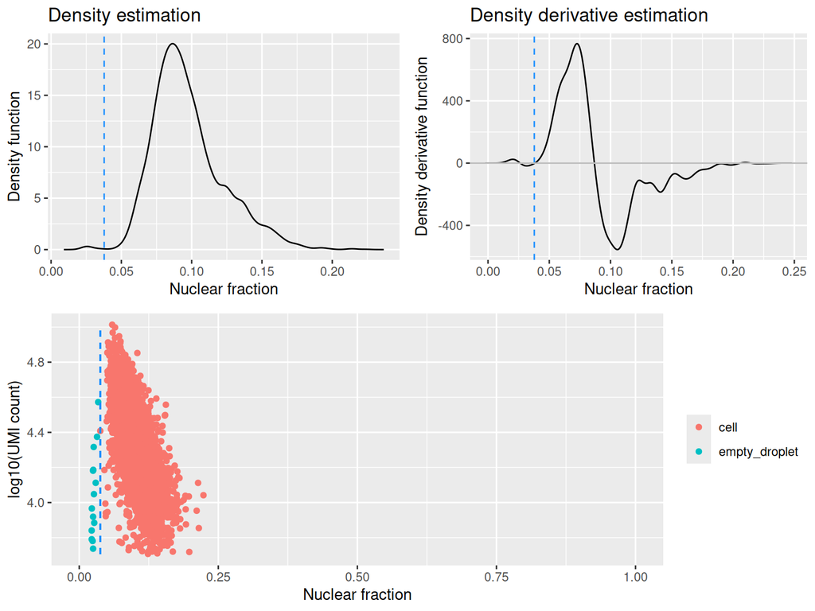

```r
# Prepare the data structure for the empty droplet detection algorithm
nf_umi <- data.frame(
  nf = sc_mix$nuclear_fraction,
  umi = sc_mix$sum,
  cell_line = sc_mix$cell_line
)

rownames(nf_umi) <- colnames(sc_mix)

# Handle NA values
nf_umi <- nf_umi[!is.na(nf_umi$nf),]

# Evaluate call and output diagnostic empty droplet cut-off visualization
cb_mix <- identify_empty_drops(nf_umi = nf_umi, include_plot = TRUE)
```

```r
# Summary table of cell status
table(cb_mix$cell_status)
```

```
         cell empty_droplet
         3904            14
```

## Investigation of possible association between empty droplets, cell identity and MALAT1 gene

Add the cell status column in the coldata of sc_mix

```r
sc_mix$cell_status <- cb_mix[colnames(sc_mix), "cell_status"]
```

```r
table(sc_mix$cell_line, sc_mix$cell_status)
```

```
         cell empty_droplet
  A549   1243             1
  H1975   510             5
  H2228   749             2
  H838    838             2
  HCC827  564             4
```

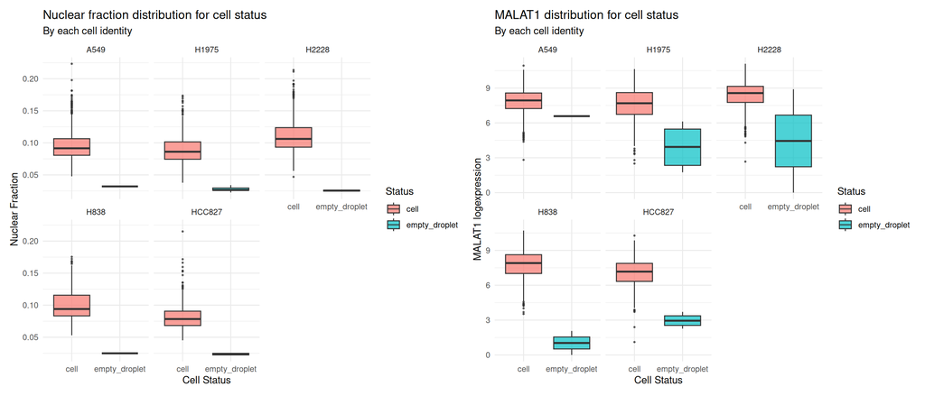

```r
p1 <- sc_mix[, !is.na(sc_mix$cell_status)] |>
  ggcells(aes(x = cell_status, y = nuclear_fraction, fill = cell_status)) +
  geom_boxplot(alpha = 0.7, outlier.size = 0.5) +
  facet_wrap(~ cell_line) +
  theme_minimal() +
  labs(
    title = "Nuclear fraction distribution for cell status",
    subtitle = "By each cell identity",
    x = "Cell Status",
    y = "Nuclear Fraction",
    fill = "Status"
  )

p2 <- sc_mix[, !is.na(sc_mix$cell_status)] |>
  ggcells(aes(x = cell_status, y = MALAT1, fill = cell_status)) +
  geom_boxplot(alpha = 0.7, outlier.size = 0.5) +
  facet_wrap(~ cell_line) +
  theme_minimal() +
  labs(
    title = "MALAT1 distribution for cell status",
    subtitle = "By each cell identity",
    x = "Cell Status",
    y = "MALAT1 logexpression",
    fill = "Status"
  )

p1 | p2
```

### Damaged Cell Identification

We isolate cells suffering from experimental stress or cellular damage by aligning properties against our benchmarked cell lines.

```r
# Reorder metadata columns with dplyr relocate using cell_line
cb_mix <- cb_mix |>
  relocate(cell_line, .after = cell_status)

# Identify cell-damage status using DropletQC
cb_mix_dc <- identify_damaged_cells(cb_mix, verbose = FALSE, output_plots = TRUE)

# Show classification output cross-tabulated across the populations
table(cb_mix_dc[[1]]$cell_status)
```

```
         cell empty_droplet
         3904            14
```

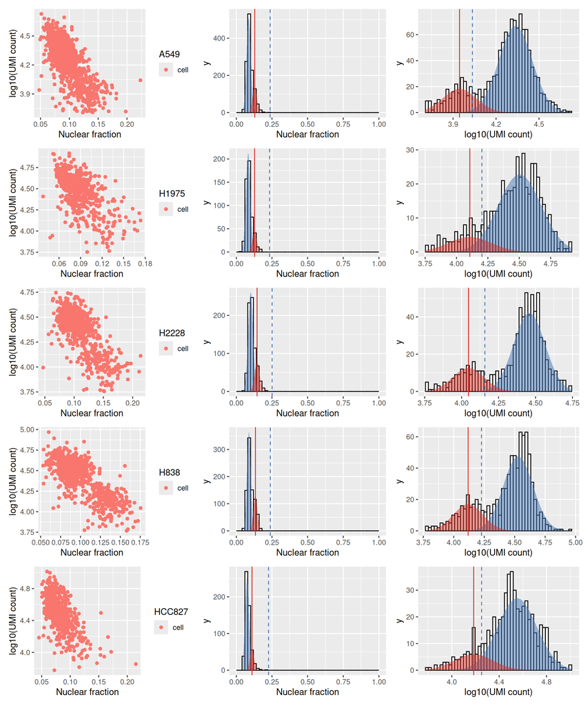

```r
# Generate multi-panel structural QC diagnostics plots
wrap_plots(cb_mix_dc[[2]], nrow = 5)
```

# Last plots: UMAP damaged and empty droplets

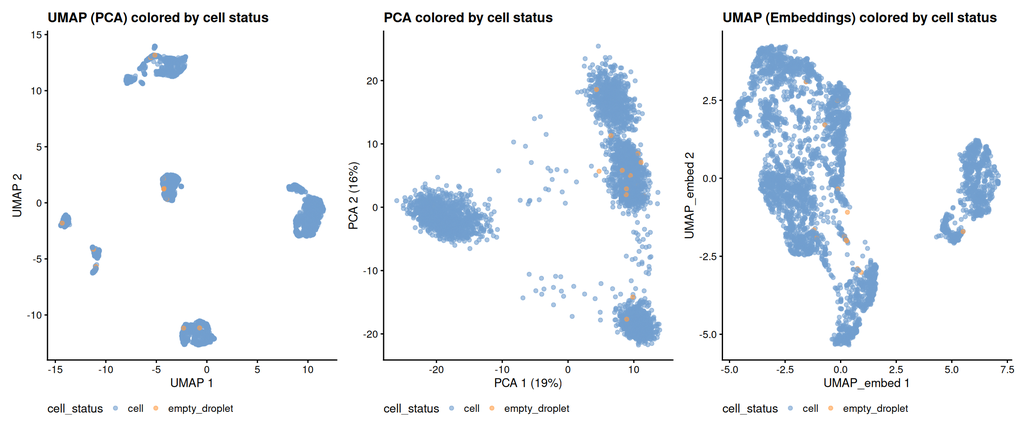

```r
umapc <- plotUMAP(sc_mix, colour_by = "cell_status") + theme(legend.position = "bottom") +
  labs(title = "UMAP (PCA) colored by cell status")
pcam  <- plotPCA(sc_mix, colour_by = "cell_status") + theme(legend.position = "bottom") +
  labs(title = "PCA colored by cell status")
umapec <- plotUMAP(sc_mix, colour_by = "cell_status", dimred = "UMAP_embed") + theme(legend.position = "bottom") +
  labs(title = "UMAP (Embeddings) colored by cell status")

umapc | pcam | umapec
```

and the relationship between cell status and MALAT1 expression in the embeddings

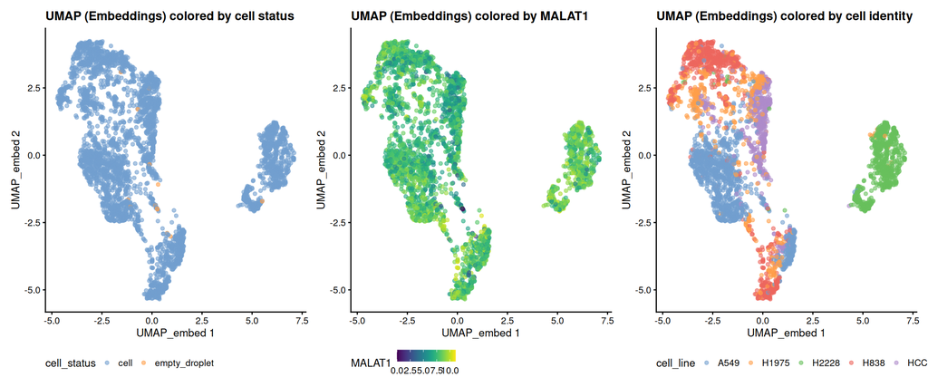

```r
umapec | umapem | umapes
```